# 2021 Cálculo do IGC Ranking

# PROBLEMA

Calcular a posição dos cursos da UFTM no ranking IGC.

Para conhecer o desempenho das instituições de ensino superior do país, os estudantes podem consultar, entre outros indicadores, o Índice Geral de Cursos (IGC). O instrumento é construído com base numa média ponderada das notas dos cursos de graduação e pós-graduação de cada instituição. Assim, sintetiza num único indicador a qualidade de todos os cursos de graduação, mestrado e doutorado da mesma instituição de ensino. O IGC é divulgado anualmente pelo Inep/MEC, imediatamente após a divulgação dos resultados do Enade.

# DATASET

https://www.gov.br/inep/pt-br/acesso-a-informacao/dados-abertos/indicadores-educacionais/indicadores-de-qualidade-da-educacao-superior

CARREGAR OS MÓDULOS

```r
library(readxl)
library(dplyr)
library(ggplot2)
library(ggcorrplot)
```

CARREGAR O DATASET

```r
dados <- read_excel("DADOS/IGC_2019.xlsx")
dados <- as.data.frame(dados)
```

VERIFICAR O NOME DAS COLUNAS DO DATASET

```r
colnames(dados)
```

```
 [1] "Ano"                                           "Código da IES"
 [3] "Nome da IES"                                   "Sigla da IES"
 [5] "Organização Acadêmica"                         "Categoria Administrativa"
 [7] "Sigla da UF"                                   "Nº de Cursos com CPC no triênio"
 [9] "Alfa (Proporção de Graduação)"                 "Conceito Médio de Graduação"
[11] "Beta (Proporção de Mestrado - Equivalente)"    "Conceito Médio de Mestrado"
[13] "Gama (Proporção de Doutorandos – Equivalente)" "Conceito Médio do doutorado"
[15] "IGC (Contínuo)"                                "IGC (Faixa)"
[17] "TX_OBS"
```

VERIFICAR O NOME DAS LINHAS

```r
rownames(dados)[1:20]
```

```
 [1] "1"  "2"  "3"  "4"  "5"  "6"  "7"  "8"  "9"  "10" "11" "12" "13" "14" "15" "16" "17" "18" "19" "20"
```

VERIFICAR O TAMANHA DO DATASET

```r
dim(dados)
```

```
[1] 2090   17
```

VERIFICAR OS TIPOS DE DADOS DO DATASET

```r
str(dados)
```

```
'data.frame':   2090 obs. of  17 variables:
 $ Ano                                          : num  2019 2019 2019 2019 2019 ...
 $ Código da IES                                : num  1 2 3 4 5 6 7 8 9 10 ...
 $ Nome da IES                                  : chr  "UNIVERSIDADE FEDERAL DE MATO GROSSO" "UNIVERSIDADE DE BRASÍLIA" "UNIVERSIDADE FEDERAL DE SERGIPE" "UNIVERSIDADE FEDERAL DO AMAZONAS" ...
 $ Sigla da IES                                 : chr  "UFMT" "UNB" "UFS" "UFAM" ...
 $ Organização Acadêmica                        : chr  "Universidade" "Universidade" "Universidade" "Universidade" ...
 $ Categoria Administrativa                     : chr  "Pública Federal" "Pública Federal" "Pública Federal" "Pública Federal" ...
 $ Sigla da UF                                  : chr  "MT" "DF" "SE" "AM" ...
 $ Nº de Cursos com CPC no triênio              : num  91 87 90 75 77 44 58 63 47 70 ...
 $ Alfa (Proporção de Graduação)                : chr  "0.79335476959999995" "0.52436395869999997" "0.80141717700000004" "0.84858188469999996" ...
 $ Conceito Médio de Graduação                  : chr  "2.9249620906999998" "3.2695857893000002" "3.1054996969999999" "2.8218514477999999" ...
 $ Beta (Proporção de Mestrado - Equivalente)   : chr  "0.13380493030000001" "0.23254033800000001" "0.1218487395" "0.1029658432" ...
 $ Conceito Médio de Mestrado                   : chr  "4.2998462327000002" "4.5884405054000004" "4.2752605347000001" "4.2343665035000004" ...
 $ Gama (Proporção de Doutorandos – Equivalente): chr  "7.2840300100000005E-2" "0.24309570329999999" "7.6734083499999994E-2" "4.8452271999999998E-2" ...
 $ Conceito Médio do doutorado                  : chr  "4.6765927977999997" "4.7726399230999998" "4.6636069113999996" "4.4914196567999998" ...
 $ IGC (Contínuo)                               : num  3.24 3.94 3.37 3.05 2.96 ...
 $ IGC (Faixa)                                  : chr  "4" "4" "4" "4" ...
 $ TX_OBS                                       : logi  NA NA NA NA NA NA ...
```

VERIFICAR OS TIPOS DE DADOS DO DATASET

```r
glimpse(dados)
```

```
Rows: 2,090
Columns: 17
$ Ano                                             <dbl> 2019, 2019, 2019, 2019, 2019, 2019, 2019, 2019, 201~
$ `Código da IES`                                 <dbl> 1, 2, 3, 4, 5, 6, 7, 8, 9, 10, 11, 12, 13, 14, 15, ~
$ `Nome da IES`                                   <chr> "UNIVERSIDADE FEDERAL DE MATO GROSSO", "UNIVERSIDAD~
$ `Sigla da IES`                                  <chr> "UFMT", "UNB", "UFS", "UFAM", "UFPI", "UFOP", "UFSC~
$ `Organização Acadêmica`                         <chr> "Universidade", "Universidade", "Universidade", "Un~
$ `Categoria Administrativa`                      <chr> "Pública Federal", "Pública Federal", "Pública Fede~
$ `Sigla da UF`                                   <chr> "MT", "DF", "SE", "AM", "PI", "MG", "SP", "MG", "PR~
$ `Nº de Cursos com CPC no triênio`               <dbl> 91, 87, 90, 75, 77, 44, 58, 63, 47, 70, 29, 43, 103~
$ `Alfa (Proporção de Graduação)`                 <chr> "0.79335476959999995", "0.52436395869999997", "0.80~
$ `Conceito Médio de Graduação`                   <chr> "2.9249620906999998", "3.2695857893000002", "3.1054~
$ `Beta (Proporção de Mestrado - Equivalente)`    <chr> "0.13380493030000001", "0.23254033800000001", "0.12~
$ `Conceito Médio de Mestrado`                    <chr> "4.2998462327000002", "4.5884405054000004", "4.2752~
$ `Gama (Proporção de Doutorandos – Equivalente)` <chr> "7.2840300100000005E-2", "0.24309570329999999", "7.~
$ `Conceito Médio do doutorado`                   <chr> "4.6765927977999997", "4.7726399230999998", "4.6636~
$ `IGC (Contínuo)`                                <dbl> 3.236518, 3.941659, 3.367594, 3.048187, 2.960657, 3~
$ `IGC (Faixa)`                                   <chr> "4", "4", "4", "4", "4", "4", "5", "5", "4", "4", "~
$ TX_OBS                                          <lgl> NA, NA, NA, NA, NA, NA, NA, NA, NA, NA, NA, NA, NA,~
```

VERIFICAR A QUANTIDADE DE VALORES ÚNICOS

```r
sapply(dados, function(x) length(unique(x)))
```

```
                                          Ano                                 Código da IES
                                            1                                          2090
                                  Nome da IES                                  Sigla da IES
                                         2070                                          1549
                        Organização Acadêmica                      Categoria Administrativa
                                            5                                             6
                                  Sigla da UF               Nº de Cursos com CPC no triênio
                                           27                                           103
                Alfa (Proporção de Graduação)                   Conceito Médio de Graduação
                                          337                                          2071
   Beta (Proporção de Mestrado - Equivalente)                    Conceito Médio de Mestrado
                                          335                                           222
Gama (Proporção de Doutorandos – Equivalente)                   Conceito Médio do doutorado
                                          211                                           123
                               IGC (Contínuo)                                   IGC (Faixa)
                                         2071                                             6
                                       TX_OBS
                                            1
```

VERIFICAR O RESUMO DO DATASET

```r
summary(dados)
```

```
      Ano       Código da IES   Nome da IES        Sigla da IES       Organização Acadêmica
 Min.   :2019   Min.   :    1   Length:2090        Length:2090        Length:2090
 1st Qu.:2019   1st Qu.: 1144   Class :character   Class :character   Class :character
 Median :2019   Median : 2044   Mode  :character   Mode  :character   Mode  :character
 Mean   :2019   Mean   : 3994
 3rd Qu.:2019   3rd Qu.: 4106
 Max.   :2019   Max.   :23410

 Categoria Administrativa Sigla da UF        Nº de Cursos com CPC no triênio Alfa (Proporção de Graduação)
 Length:2090              Length:2090        Min.   :  0.00                  Length:2090
 Class :character         Class :character   1st Qu.:  2.00                  Class :character
 Mode  :character         Mode  :character   Median :  5.00                  Mode  :character
                                             Mean   : 11.55
                                             3rd Qu.: 11.00
                                             Max.   :713.00

 Conceito Médio de Graduação Beta (Proporção de Mestrado - Equivalente) Conceito Médio de Mestrado
 Length:2090                 Length:2090                                Length:2090
 Class :character            Class :character                           Class :character
 Mode  :character            Mode  :character                           Mode  :character




 Gama (Proporção de Doutorandos – Equivalente) Conceito Médio do doutorado IGC (Contínuo)
 Length:2090                                   Length:2090                 Min.   :0.7498
 Class :character                              Class :character            1st Qu.:2.2099
 Mode  :character                              Mode  :character            Median :2.5493
                                                                           Mean   :2.5765
                                                                           3rd Qu.:2.9228
                                                                           Max.   :4.8549
                                                                           NA's   :20
 IGC (Faixa)         TX_OBS
 Length:2090        Mode:logical
 Class :character   NA's:2090
 Mode  :character
```

VERIFICAR A QUANTIDADE DE VALORES MISSING

```r
sapply(dados, function(x) sum(is.na(x)))
```

```
                                          Ano                                 Código da IES
                                            0                                             0
                                  Nome da IES                                  Sigla da IES
                                            0                                           316
                        Organização Acadêmica                      Categoria Administrativa
                                            0                                             0
                                  Sigla da UF               Nº de Cursos com CPC no triênio
                                            0                                             0
                Alfa (Proporção de Graduação)                   Conceito Médio de Graduação
                                            0                                             0
   Beta (Proporção de Mestrado - Equivalente)                    Conceito Médio de Mestrado
                                            0                                             0
Gama (Proporção de Doutorandos – Equivalente)                   Conceito Médio do doutorado
                                            0                                             0
                               IGC (Contínuo)                                   IGC (Faixa)
                                           20                                             0
                                       TX_OBS
                                         2090
```

VERIFICAR A QUANTIDADE DE VALORES NULOS

```r
sapply(dados, function(x) sum(is.null(x)))
```

```
                                          Ano                                 Código da IES
                                            0                                             0
                                  Nome da IES                                  Sigla da IES
                                            0                                             0
                        Organização Acadêmica                      Categoria Administrativa
                                            0                                             0
                                  Sigla da UF               Nº de Cursos com CPC no triênio
                                            0                                             0
                Alfa (Proporção de Graduação)                   Conceito Médio de Graduação
                                            0                                             0
   Beta (Proporção de Mestrado - Equivalente)                    Conceito Médio de Mestrado
                                            0                                             0
Gama (Proporção de Doutorandos – Equivalente)                   Conceito Médio do doutorado
                                            0                                             0
                               IGC (Contínuo)                                   IGC (Faixa)
                                            0                                             0
                                       TX_OBS
                                            0
```

VERIFICAR AS PRIMEIRAS LINHAS DO DATASET

```r
head(dados, 5)
```

```
   Ano Código da IES                         Nome da IES Sigla da IES Organização Acadêmica
1 2019             1 UNIVERSIDADE FEDERAL DE MATO GROSSO         UFMT          Universidade
2 2019             2            UNIVERSIDADE DE BRASÍLIA          UNB          Universidade
3 2019             3     UNIVERSIDADE FEDERAL DE SERGIPE          UFS          Universidade
4 2019             4    UNIVERSIDADE FEDERAL DO AMAZONAS         UFAM          Universidade
5 2019             5       UNIVERSIDADE FEDERAL DO PIAUÍ         UFPI          Universidade
  Categoria Administrativa Sigla da UF Nº de Cursos com CPC no triênio Alfa (Proporção de Graduação)
1          Pública Federal          MT                              91           0.79335476959999995
2          Pública Federal          DF                              87           0.52436395869999997
3          Pública Federal          SE                              90           0.80141717700000004
4          Pública Federal          AM                              75           0.84858188469999996
5          Pública Federal          PI                              77           0.85508329439999997
  Conceito Médio de Graduação Beta (Proporção de Mestrado - Equivalente) Conceito Médio de Mestrado
1          2.9249620906999998                        0.13380493030000001         4.2998462327000002
2          3.2695857893000002                        0.23254033800000001         4.5884405054000004
3          3.1054996969999999                               0.1218487395         4.2752605347000001
4          2.8218514477999999                               0.1029658432         4.2343665035000004
5                2.7132830196                               0.1002335357         4.3096076458999999
  Gama (Proporção de Doutorandos – Equivalente) Conceito Médio do doutorado IGC (Contínuo) IGC (Faixa)
1                         7.2840300100000005E-2          4.6765927977999997       3.236518           4
2                           0.24309570329999999          4.7726399230999998       3.941659           4
3                         7.6734083499999994E-2          4.6636069113999996       3.367594           4
4                         4.8452271999999998E-2          4.4914196567999998       3.048187           4
5                                 4.46831699E-2          4.6685667752000004       2.960657           4
  TX_OBS
1     NA
2     NA
3     NA
4     NA
5     NA
```

VERIFICAR AS ÚLTIMAS LINHAS DO DATASET

```r
tail(dados)
```

```
      Ano Código da IES                                           Nome da IES    Sigla da IES
2085 2019         19861                      Faculdade de Santana de Parnaíba            FASP
2086 2019         19862            Faculdade de Tecnologia Jorge Caram Sabbag FATEC Bebedouro
2087 2019         19863                      Faculdade de Tecnologia de Assis     FATEC Assis
2088 2019         20478        Faculdade de Tecnologia de Santana de Parnaíba       FATEC-SPB
2089 2019         22015       Faculdade Municipal de Educação e Meio Ambiente            FAMA
2090 2019         23410 UNIVERSIDADE ESTADUAL DA REGIÃO TOCANTINA DO MARANHÃO         UEMASUL
     Organização Acadêmica    Categoria Administrativa Sigla da UF Nº de Cursos com CPC no triênio
2085             Faculdade Privada sem fins lucrativos          SP                               1
2086             Faculdade            Pública Estadual          SP                               1
2087             Faculdade            Pública Estadual          SP                               1
2088             Faculdade            Pública Estadual          SP                               1
2089             Faculdade           Pública Municipal          PR                               1
2090          Universidade            Pública Estadual          MA                               4
     Alfa (Proporção de Graduação) Conceito Médio de Graduação Beta (Proporção de Mestrado - Equivalente)
```

[output cut: 20 more lines]

VERIFIAR VALORES ALEATÓRIOS DO DATASET

```r
sample_n(dados, 5)
```

```
   Ano Código da IES                                           Nome da IES Sigla da IES
1 2019          1373                                 FACULDADE CASA BRANCA        FACAB
2 2019          2917                                FACULDADE BRASIL NORTE       FABRAN
3 2019          3675             SINAL - FACULDADE DE TEOLOGIA E FILOSOFIA        SINAL
4 2019          3754     FACULDADES INTEGRADAS ADVENTISTAS DE MINAS GERAIS     FADMINAS
5 2019          4751 FACULDADE DE TECNOLOGIA E CIENCIAS DO NORTE DO PARANÁ      FATECIE
  Organização Acadêmica    Categoria Administrativa Sigla da UF Nº de Cursos com CPC no triênio
1             Faculdade Privada com fins lucrativos          SP                               2
2             Faculdade Privada com fins lucrativos          AP                               5
3             Faculdade Privada sem fins lucrativos          AC                               1
4             Faculdade Privada sem fins lucrativos          MG                               2
5  Centro Universitário Privada com fins lucrativos          PR                               5
  Alfa (Proporção de Graduação) Conceito Médio de Graduação Beta (Proporção de Mestrado - Equivalente)
1                             1          3.3590115161999998                                          0
2                             1                1.8658060449                                          0
3                             1          1.2450650750000001                                          0
4                             1          2.3650319622999998                                          0
5                             1          2.7631630723999998                                          0
  Conceito Médio de Mestrado Gama (Proporção de Doutorandos – Equivalente) Conceito Médio do doutorado
1                          0                                             0                           0
2                          0                                             0                           0
3                          0                                             0                           0
4                          0                                             0                           0
5                          0                                             0                           0
  IGC (Contínuo) IGC (Faixa) TX_OBS
1       3.359012           4     NA
2       1.865806           2     NA
3       1.245065           2     NA
4       2.365032           3     NA
5       2.763163           3     NA
```

VERIFICAR A QUANTIDADE DE VALORES MISSING DA VARIÁVEL

```r
dim(dados[is.na(dados$`IGC (Contínuo)`), ])
```

```
[1] 20 17
```

VERIFICAR OS REGISTROS QUE TEM VALORES MISSING

```r
dados[is.na(dados$`IGC (Contínuo)`), ]
```

```
      Ano Código da IES                                            Nome da IES Sigla da IES
322  2019           651     FACULDADE DE ADMINISTRAÇÃO DE GOVERNADOR VALADARES         FAGV
353  2019           708                INSTITUTO DE CIÊNCIAS SOCIAIS APLICADAS         UNEB
466  2019          1034                  UNIÃO DE ESCOLAS SUPERIORES DA FUNESO        UNESF
489  2019          1072                                   FACULDADE AFIRMATIVO         FAFI
717  2019          1501                 FACULDADE LATINO AMERICANA DE EDUCAÇÃO       FLATED
797  2019          1628                 FACULDADE DE CIÊNCIAS HUMANAS DE AGUAÍ        FACHA
950  2019          1865                            Faculdade Alvorada Paulista         FALP
1052 2019          2075                INSTITUTO DE ENSINO SUPERIOR DE ALAGOAS         IESA
1215 2019          2566                 INSTITUTO DE ENSINO SUPERIOR DE OLINDA         IESO
1305 2019          2927                            FACULDADE DE BELO HORIZONTE          FDR
1367 2019          3307                                 FACULDADE DE RIO CLARO         CBTA
1562 2019          4095 FACULDADE DE TECNOLOGIA E CIÊNCIAS DO DISTRITO FEDERAL      FATECDF
1645 2019          4605                         FACULDADE DE CORNÉLIO PROCÓPIO         <NA>
1668 2019          4739                 FACULDADE PRESBITERIANA AUGUSTO GALVÃO        FAPAG
```

[output cut: 90 more lines]

EXCLUIR OS REGISTROS COM VALORES MISSING

```r
dados <- dados[!is.na(dados$`IGC (Contínuo)`), ]
```

PLOTAR HISTROGRAMA

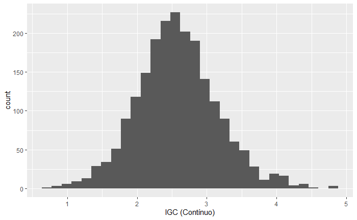

```r
ggplot(dados) +
  aes(x = `IGC (Contínuo)`) +
  geom_histogram()
```

PLOTAR BOXPLOT

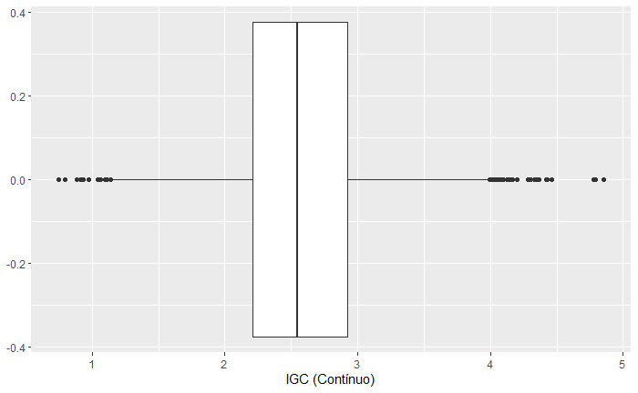

```r
ggplot(dados) +
  aes(x = `IGC (Contínuo)`) +
  geom_boxplot()
```

VERIFICAR A MÉDIA POR UF

```r
filtro <- dados %>%
  group_by(`Sigla da UF`) %>%
  summarise( media = mean(`IGC (Contínuo)`)) %>%
  arrange(media)


levels <- filtro$`Sigla da UF`
filtro$`Sigla da UF` <- factor(filtro$`Sigla da UF`, levels=levels, ordered=TRUE)

filtro
```

```
# A tibble: 27 x 2
   `Sigla da UF` media
   <ord>         <dbl>
 1 AL             2.21
 2 AP             2.22
 3 TO             2.32
 4 PI             2.39
 5 MS             2.39
 6 MT             2.40
 7 PE             2.41
 8 PA             2.47
 9 MA             2.49
10 AM             2.49
# ... with 17 more rows
```

PLOTAR A MÉDIA POR UF

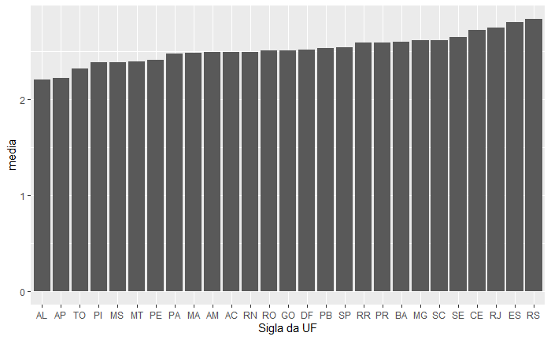

```r
filtro %>%
  ggplot(aes(x = `Sigla da UF`, y = media)) +
  geom_col()
```

PLOTAR O BOXPLOT POR UF

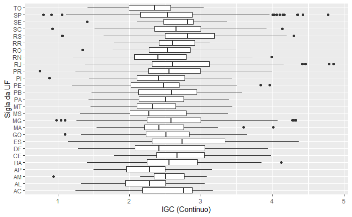

```r
ggplot(dados, aes(x = `IGC (Contínuo)`, y = `Sigla da UF`)) +
  geom_boxplot()
```

VERIFICAR A MÉDIA POR CATEGORIA ADM

```r
filtro <- dados %>%
  group_by(`Categoria Administrativa`) %>%
  summarise( media = mean(`IGC (Contínuo)`)) %>%
  arrange(media)


levels <- filtro$`Categoria Administrativa`
filtro$`Categoria Administrativa` <- factor(filtro$`Categoria Administrativa`,
                                            levels=levels, ordered=TRUE)

filtro
```

```
# A tibble: 6 x 2
  `Categoria Administrativa`  media
  <ord>                       <dbl>
1 Especial                     2.21
2 Pública Municipal            2.33
3 Privada com fins lucrativos  2.48
4 Privada sem fins lucrativos  2.60
5 Pública Estadual             2.79
6 Pública Federal              3.28
```

PLOTAR A MÉDIA POR CATEGORIA ADM

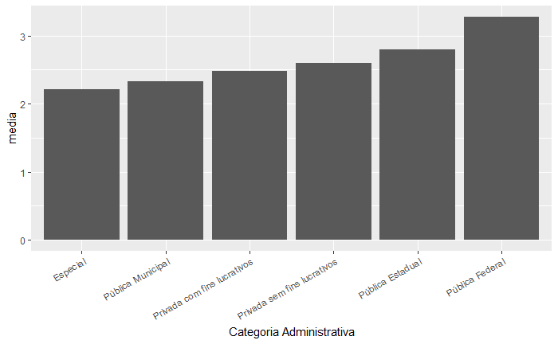

```r
filtro %>%
  ggplot(aes(x = `Categoria Administrativa`, y = media)) +
  geom_col() +
  theme(axis.text.x = element_text(angle = 30, vjust = 1, hjust=1))
```

PLOTAR O BOXPLOT POR CATEGORIA ADM

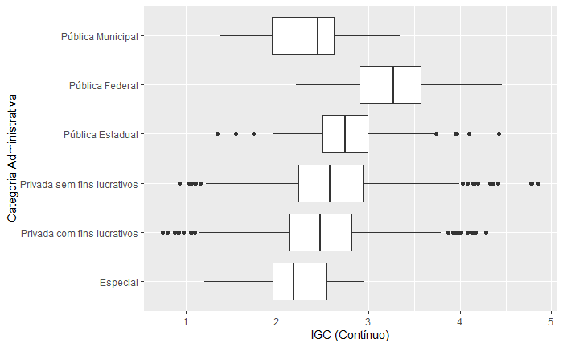

```r
ggplot(dados, aes(x = `IGC (Contínuo)`, y = `Categoria Administrativa`)) +
  geom_boxplot()
```

VERIFICAR A MÉDIA POR ORGANIZAÇÃO ACADÊMICA

```r
filtro <- dados %>%
  group_by(`Organização Acadêmica`) %>%
  summarise( media = mean(`IGC (Contínuo)`)) %>%
  arrange(media)


levels <- filtro$`Organização Acadêmica`
filtro$`Organização Acadêmica` <- factor(filtro$`Organização Acadêmica`,
                                            levels=levels, ordered=TRUE)

filtro
```

```
# A tibble: 5 x 2
  `Organização Acadêmica`                             media
  <ord>                                               <dbl>
1 Faculdade                                            2.45
2 Centro Universitário                                 2.82
3 Instituto Federal de Educação, Ciência e Tecnologia  2.83
4 Universidade                                         3.11
5 Centro Federal de Educação Tecnológica               3.51
```

PLOTAR A MÉDIA POR ORGANIZAÇÃO ACADÊMICA

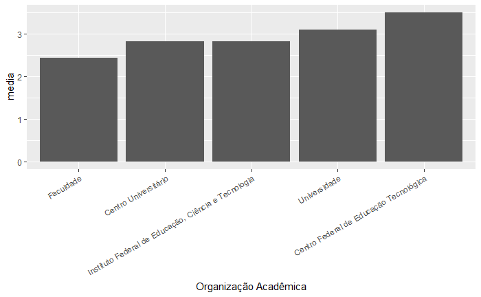

```r
filtro %>%
  ggplot(aes(x = `Organização Acadêmica`, y = media)) +
  geom_col() +
  theme(axis.text.x = element_text(angle = 30, vjust = 1, hjust=1))
```

PLOTAR O BOXPLOT POR ORGANIZAÇÃO ACADÊMICA

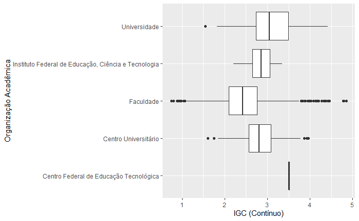

```r
ggplot(dados, aes(x = `IGC (Contínuo)`, y = `Organização Acadêmica`)) +
  geom_boxplot()
```

PLOTAR A QUANTIDADE DE ORGANIZAÇÃO ACADÊMICA

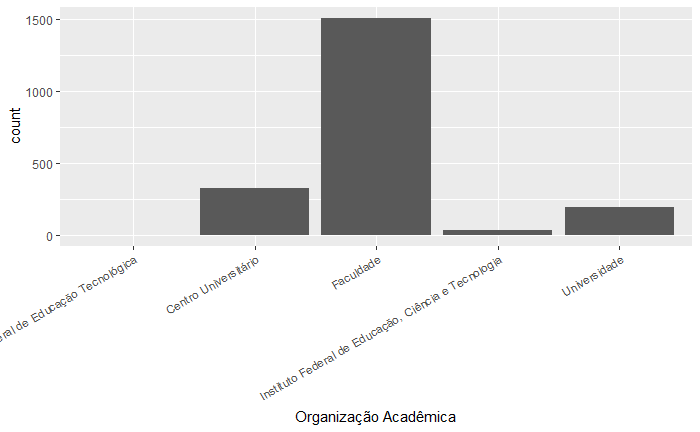

```r
ggplot(dados, aes(x = `Organização Acadêmica`)) +
  geom_bar() +
  theme(axis.text.x = element_text(angle = 30, vjust = 1, hjust=1))
```

CONVERTER AS VARIÁVEIS DE TEXTO PARA NUMÉRICO

```r
colunas <- c("Nº de Cursos com CPC no triênio",
"Alfa (Proporção de Graduação)",
"Conceito Médio de Graduação",
"Beta (Proporção de Mestrado - Equivalente)",
"Conceito Médio de Mestrado",
"Gama (Proporção de Doutorandos – Equivalente)",
"Conceito Médio do doutorado",
"IGC (Contínuo)",
"IGC (Faixa)" )

for (cl in colunas){
  dados[cl] <- as.double(dados[, cl])
}

cor(dados[, colunas])
```

```
                                              Nº de Cursos com CPC no triênio Alfa (Proporção de Graduação)
Nº de Cursos com CPC no triênio                                     1.0000000                    -0.2681261
Alfa (Proporção de Graduação)                                      -0.2681261                     1.0000000
Conceito Médio de Graduação                                         0.1902578                    -0.3197487
Beta (Proporção de Mestrado - Equivalente)                          0.2203062                    -0.9579571
Conceito Médio de Mestrado                                          0.5139914                    -0.6291543
Gama (Proporção de Doutorandos – Equivalente)                       0.2966543                    -0.8872498
Conceito Médio do doutorado                                         0.5488676                    -0.6571712
IGC (Contínuo)                                                      0.2431461                    -0.4999578
IGC (Faixa)                                                         0.2066042                    -0.4550394
                                              Conceito Médio de Graduação
Nº de Cursos com CPC no triênio                                 0.1902578
Alfa (Proporção de Graduação)                                  -0.3197487
Conceito Médio de Graduação                                     1.0000000
Beta (Proporção de Mestrado - Equivalente)                      0.3217862
Conceito Médio de Mestrado                                      0.3264436
Gama (Proporção de Doutorandos – Equivalente)                   0.2588074
Conceito Médio do doutorado                                     0.2710030
IGC (Contínuo)                                                  0.9768458
IGC (Faixa)                                                     0.8772144
                                              Beta (Proporção de Mestrado - Equivalente)
Nº de Cursos com CPC no triênio                                                0.2203062
Alfa (Proporção de Graduação)                                                 -0.9579571
Conceito Médio de Graduação                                                    0.3217862
Beta (Proporção de Mestrado - Equivalente)                                     1.0000000
Conceito Médio de Mestrado                                                     0.6325637
Gama (Proporção de Doutorandos – Equivalente)                                  0.7175979
Conceito Médio do doutorado                                                    0.5922731
IGC (Contínuo)                                                                 0.4827892
IGC (Faixa)                                                                    0.4391130
                                              Conceito Médio de Mestrado
Nº de Cursos com CPC no triênio                                0.5139914
Alfa (Proporção de Graduação)                                 -0.6291543
Conceito Médio de Graduação                                    0.3264436
Beta (Proporção de Mestrado - Equivalente)                     0.6325637
Conceito Médio de Mestrado                                     1.0000000
Gama (Proporção de Doutorandos – Equivalente)                  0.5102075
Conceito Médio do doutorado                                    0.7863032
IGC (Contínuo)                                                 0.4385876
IGC (Faixa)                                                    0.3907532
                                              Gama (Proporção de Doutorandos – Equivalente)
Nº de Cursos com CPC no triênio                                                   0.2966543
Alfa (Proporção de Graduação)                                                    -0.8872498
Conceito Médio de Graduação                                                       0.2588074
Beta (Proporção de Mestrado - Equivalente)                                        0.7175979
Conceito Médio de Mestrado                                                        0.5102075
Gama (Proporção de Doutorandos – Equivalente)                                     1.0000000
Conceito Médio do doutorado                                                       0.6429946
IGC (Contínuo)                                                                    0.4373959
IGC (Faixa)                                                                       0.3985810
                                              Conceito Médio do doutorado IGC (Contínuo) IGC (Faixa)
Nº de Cursos com CPC no triênio                                 0.5488676      0.2431461   0.2066042
Alfa (Proporção de Graduação)                                  -0.6571712     -0.4999578  -0.4550394
Conceito Médio de Graduação                                     0.2710030      0.9768458   0.8772144
Beta (Proporção de Mestrado - Equivalente)                      0.5922731      0.4827892   0.4391130
Conceito Médio de Mestrado                                      0.7863032      0.4385876   0.3907532
Gama (Proporção de Doutorandos – Equivalente)                   0.6429946      0.4373959   0.3985810
Conceito Médio do doutorado                                     1.0000000      0.4001815   0.3673795
IGC (Contínuo)                                                  0.4001815      1.0000000   0.8974351
IGC (Faixa)                                                     0.3673795      0.8974351   1.0000000
```

PLOTAR AS CORRELAÇÕES

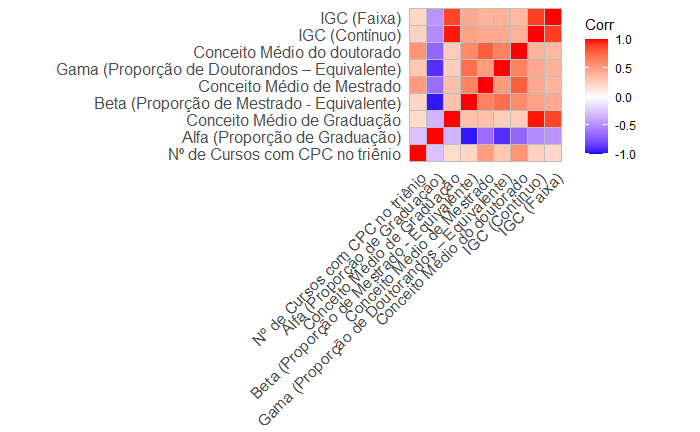

```r
ggcorrplot(cor(dados[, colunas]))
```

FUNÇÃO PARA CRIAR O RANKING DO IGC

```r
calculo_ranking_igc <- function(dados){
  "FUNÇÃO PARA CRIAR O RAMKING DO IGC
  ENTRA
    DATASET
  SAI
    RANKING POR: BR, REGIÃO, UF; NOTA, FAIXA DO CPC"

  # FILTRA OS DADOS DA INSTITUIÇÃO
  ddt <- dados %>%
    filter(`Código da IES` == 597)
  # PEGAR A NOTA E A FAIXA
  nota <- ddt$`IGC (Contínuo)`
  faixa <- ddt$`IGC (Contínuo)`

  # PEGAR A POSIÇÃO DO RANKING BR
  ddt <- dados %>%
    arrange(desc(`IGC (Contínuo)`), `Nome da IES`)

  ranking_br <- which(ddt$`Código da IES` == 597)

  # PEGAR A POSIÇÃO DO RANKING REGIÃO
  ddt <- dados %>%
  filter(`Sigla da UF` %in% c('MG', 'SP', 'RJ', 'ES')) %>%
  arrange(desc(`IGC (Contínuo)`), `Nome da IES`)

  ranking_regiao <- which(ddt$`Código da IES` == 597)

  # PEGAR A POSIÇÃO DO RANKING UF
  ddt <- dados %>%
  filter(`Sigla da UF` == 'MG') %>%
  arrange(desc(`IGC (Contínuo)`), `Nome da IES`)

  ranking_uf <- which(ddt$`Código da IES` == 597)

  return (c(ranking_br, ranking_regiao, ranking_uf, nota, faixa))
}
```

CALCULAR O RANKING

```r
tb <- calculo_ranking_igc(dados)

resultado <- as.data.frame(t(tb))
colnames(resultado) <- c('ranking_br', 'ranking_regiao', 'ranking_uf', 'IGC (Contínuo)', 'IGC (Faixa)')

resultado
```

[output not shown]

SALVAR O RESULTADO DO CÁLCULO

```r
write.csv2(resultado, file = 'RESULTADOS/CALCULO - IGC - RANKING.csv', na = "", quote = FALSE)
```